# Data Analysis and Visualization in R

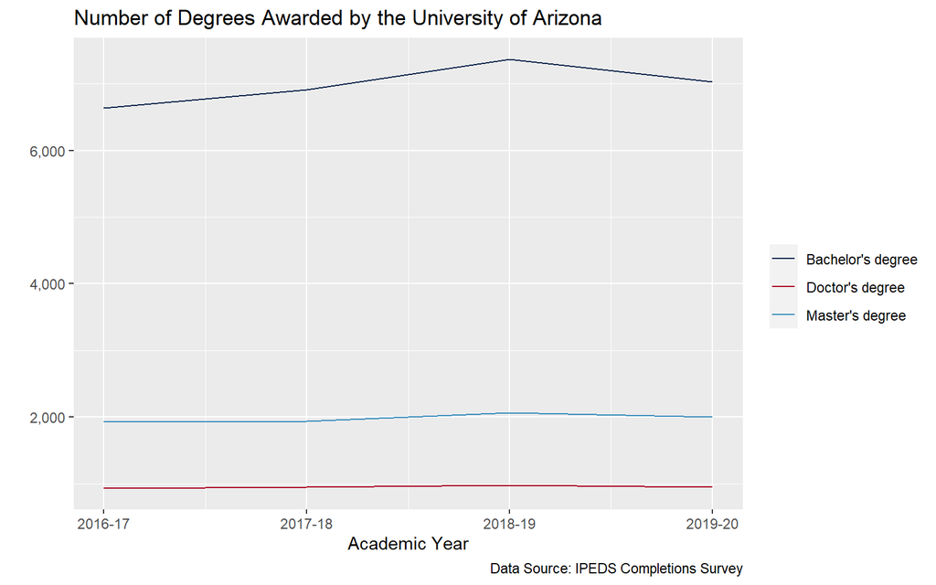

```r
# 5. Use colors other than the R defaults for the lines
# This is another application of a scale function
p_3 <- p_2 +
  scale_color_manual(values = c("#0C234B", "#AB0520", "#378DBD"))

p_3
```

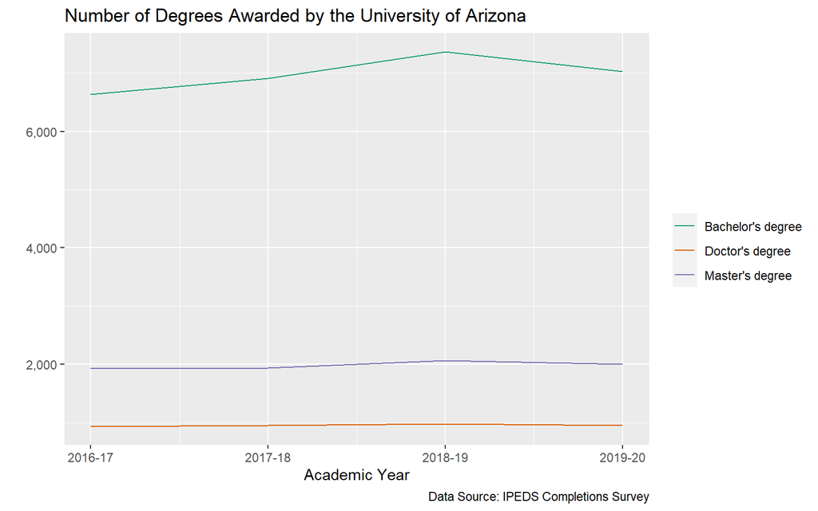

```r
# We can also use other pre-built color schemes
p_2 +
  scale_color_brewer(palette = "Dark2")
```

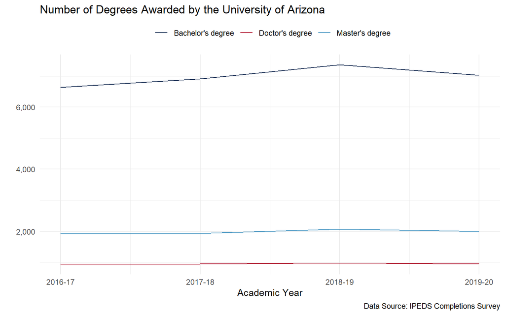

```r
# 6. Remove the grey background from the plot
# And move the legend to the top
p_4 <- p_3 +
  theme_minimal() +
  theme(legend.position = "top")

p_4
```

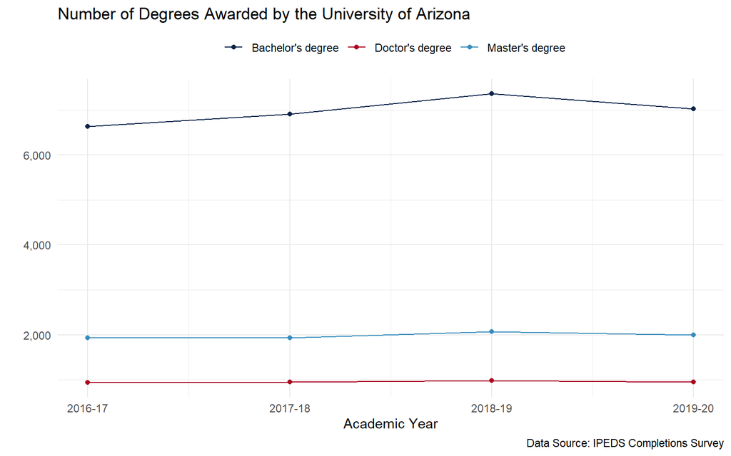

```r
# Final touch-ups
# Add a point for each year
p_5 <- p_4 +
  geom_point()

p_5
```

```r
# To remove the line in the legend, we can go back to the beginning and change geom_line() to geom_line(show.legend = FALSE)

# Save the plot
ggsave(filename = here("plots", "line_plot.png"),
       plot = p_5,
       device = "png",
       width = 8,
       height = 5,
       type = "cairo")
```

## Fixing Potential Errors

```r
# Why doesn't the code in this chunk create what we expect?

# Get the data ready for the plot
ipeds_adm_plot <- ipeds_adm %>%
  filter(year == 2019)

## 1 -  Color ##

# Not quite right
ggplot(data = ipeds_adm_plot,
       mapping = aes(x = sat_score,
                     y = act_score,
                     color = "blue")) +
  geom_point()


# Correct
ggplot(data = ipeds_adm_plot,
       mapping = aes(x = sat_score,
                     y = act_score)) +
  geom_point(color = "blue")

## 2 - Plus sign ##

# Not quite right
ggplot(data = ipeds_adm_plot,
       mapping = aes(x = sat_score,
                     y = act_score))
 + geom_point() # <- + at the beginning


ggplot(data = ipeds_adm_plot,
       mapping = aes(x = sat_score,
                     y = act_score)) # <- missing +
  geom_point()

ggplot(data = ipeds_adm_plot,
       mapping = aes(x = sat_score,
                     y = act_score)) + + # <- double +
  geom_point()

# Correct
ggplot(data = ipeds_adm_plot,
       mapping = aes(x = sat_score,
                     y = act_score)) + # Need to have a single + at the end of the line
  geom_point()


## 3 - Missing object ##

# Not quite right
ggplot(data = ipeds_adm_plot,
       mapping = aes(x = sat,
                     y = act_score)) +
  geom_point()

# Correct
ggplot(data = ipeds_adm_plot,
       mapping = aes(x = sat_score,
                     y = act_score)) +
  geom_point()

## 4 - Parentheses ##

# Not quite right
ggplot(data = ipeds_adm_plot,
       mapping = aes(x = sat_score,
                     y = act_score) + # <- missing parentheses
  geom_point()

ggplot(data = ipeds_adm_plot,
       mapping = aes(x = sat_score,
                     y = act_score))) + # <- extra parentheses
  geom_point()

# Correct
ggplot(data = ipeds_adm_plot,
       mapping = aes(x = sat_score,
                     y = act_score)) +
  geom_point()
```

## Data Visualization - Your Turn

Using the code we’ve already written, try making a new version of a plot. Use a different geometric object (i.e. replace `geom_line()` with `geom_bar()`) or change the aesthetics mappings (i.e. add a color or fill argument to the `aes()` function or switch out the variables used in the `aes()` function to visualize different values).

Make a visualization using a different IPEDS dataset.

Learn more at the package website: https://ggplot2.tidyverse.org/